# A New Approach to Generate Dorling Cartograms

Department of Mathematics  
University of Nebraska at Omaha  
JSM 2018

## What is Dorling Cartogram?

- A Dorling cartogram replaces polygons by circles with radii in proportion to a numerical thematic variable like population, birth rate, etc.
- It is an abstract display of areal data that maintains neither shape or topology.

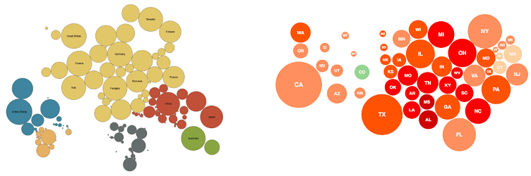

## Original algorithm

- Dorling (1996) proposed the Circular Cartogram
  - Per iteration, the algorithm
  - Computes the repelling and attracting force for each circle
  - Moves circles with restrictions

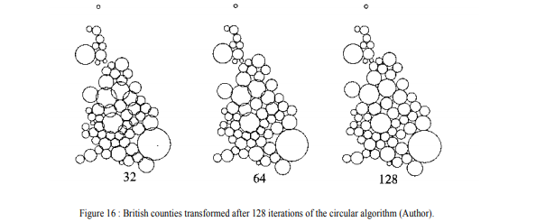

## Software applications

- Bostock (2010)
  - Pseudo-cartogram for **D3.js**
- Cheng (2014)
  - R package **cartogram**
- Rudis and Rajerison (2018)
  - R package **spdorling**
  - Creating Dorling Cartograms from shapefiles
- Bedward, Eppstein, and Menzel (2018)
  - R package **packcircles**
  - Adopted the circle packing algorithm by Collins and Stephenson (2003)

## Example: 2016 presidential election

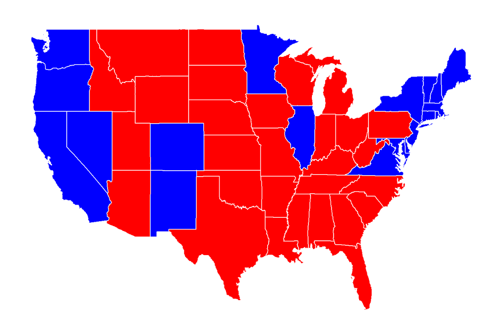

## Polygons to circles without scaling

Circle radius: square root of the number of electors

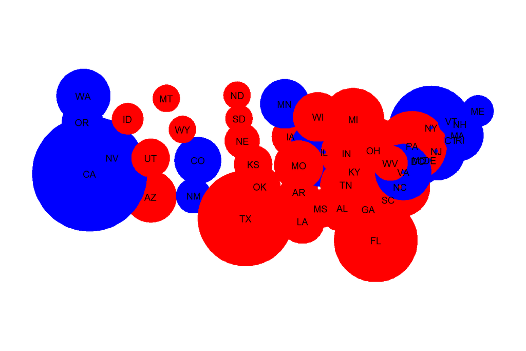

## Scaling circles to avoid overlapping

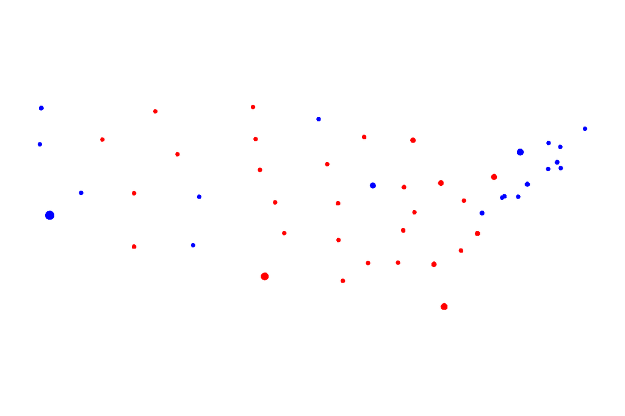

## Moderate scaling

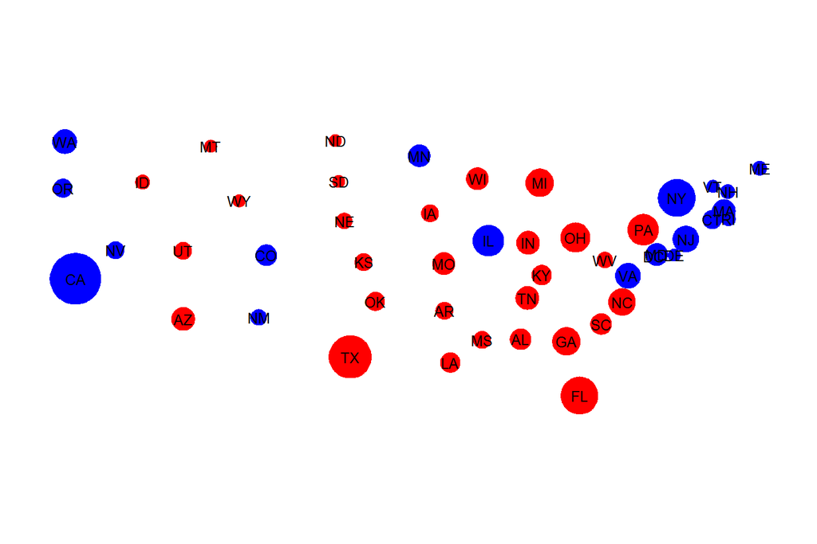

## Dorling result after 200+ iterations

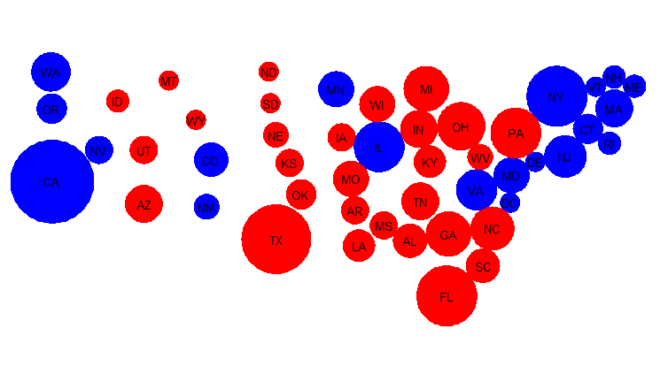

## Limitations of the original algorithm

- Need large number of iterations
- Crowded circles are easily misplaced

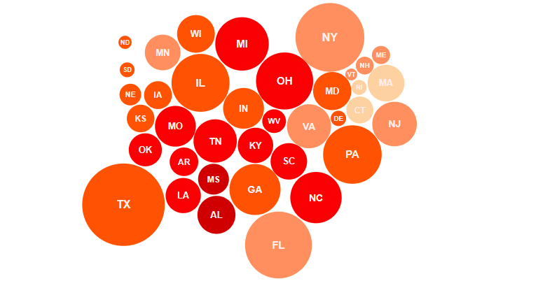

## Example of misplacement (status 0)

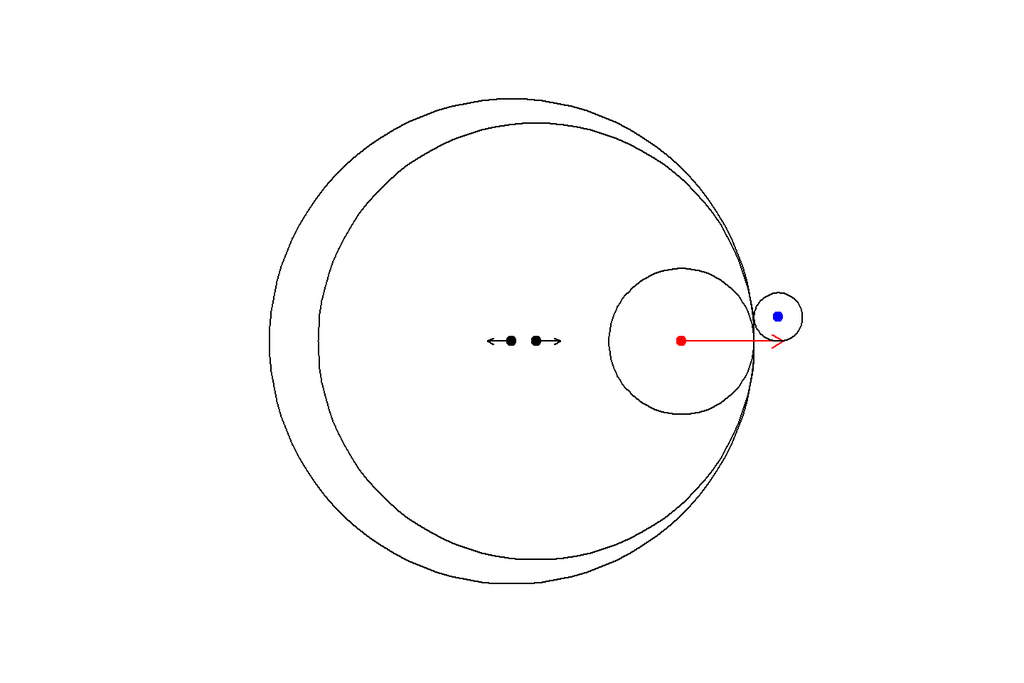

## Example of misplacement (status 1)

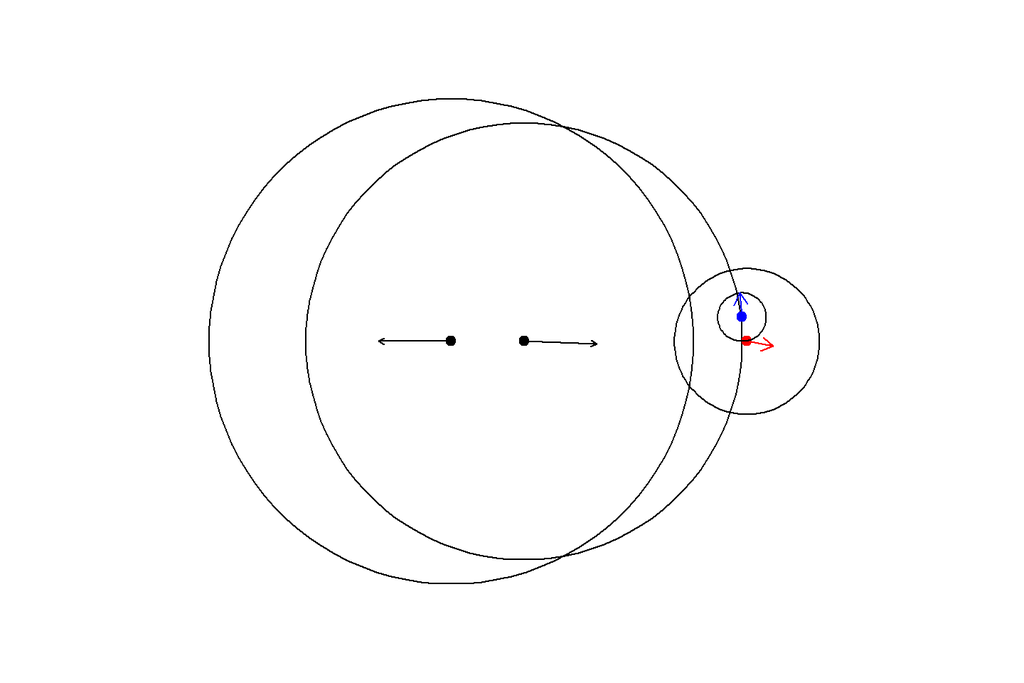

## New triangle-based approach

- Goal
  - Avoiding misplacement
  - Reducing iterations
- Idea
  - Starting with non-contiguous circles
  - Pulling them together recursively
  - Using triangles to keep topology
- Strategy
  - Linking circles by neighbors to construct triangles
  - Choosing two center circles (an edge) to start recursion
  - Calculating the pulling direction by the original triangle median

## Visual explanation

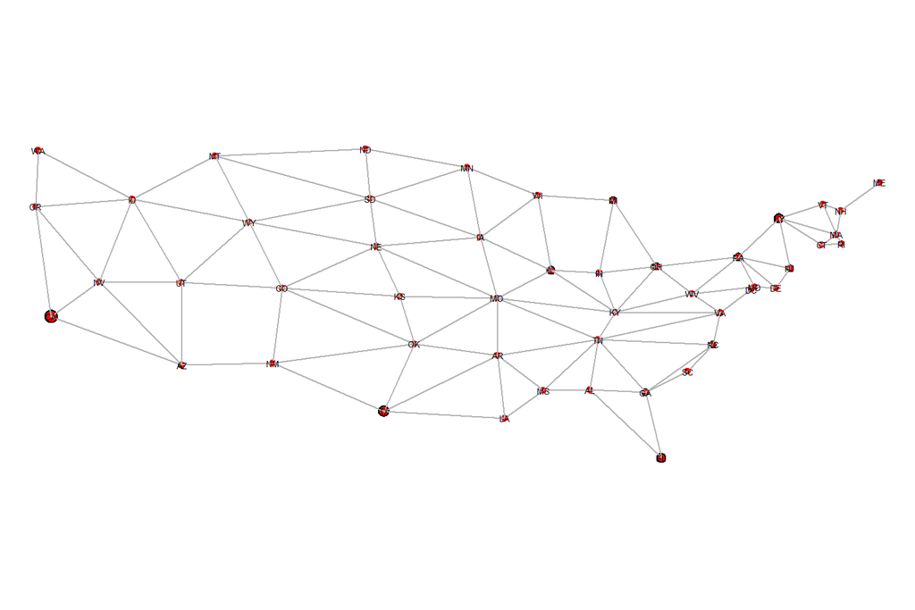

## Choice of center

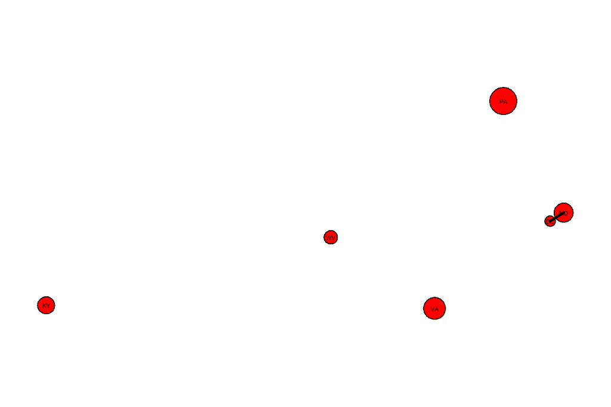

## Recursive moves

[video not shown]

## After recursion

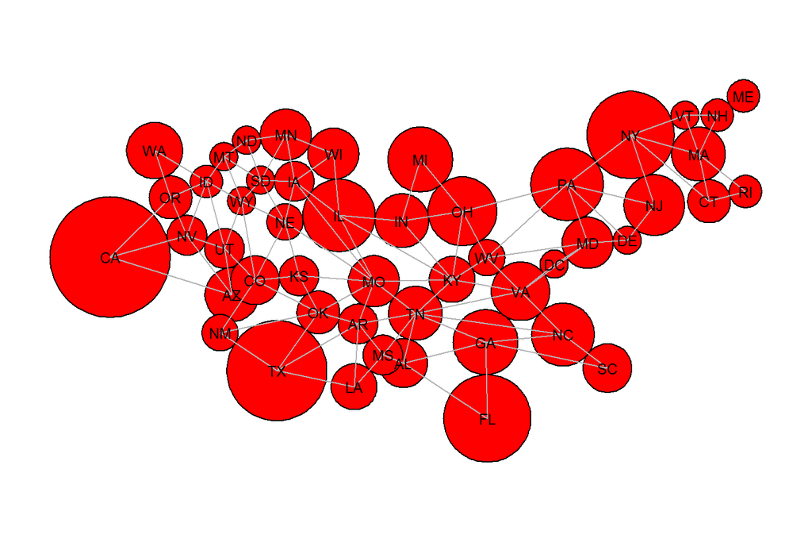

## Limitations

- The choice of centers
  - Recursive chain reaction
- Pulling direction decision
  - The slope of triangle median does not change as the opposite edge moves.

Solution: bind with the Dorling algorithm

## Final result

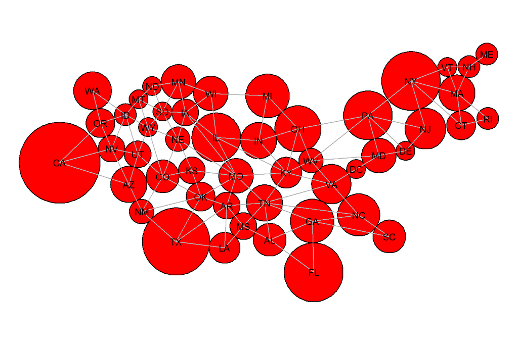

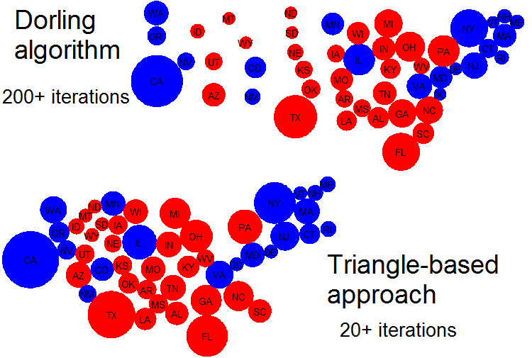

## Summary and future work

- Summary
  - Limitations of Dorling cartogram
  - Triangle-based approach
- Future work
  - Automatic center selection
  - Multiple centers initialization
  - Pulling direction flexibility

## References

1. Dorling, D. (1996). Area cartograms: their use and creation. Concepts and Techniques in Modern Geography (CATMOG).
2. Bostock, M. (2010). Protovis - Dorling Cartograms. URL: http://mbostock.github.io/protovis/ex/cartogram.html
3. Bob Rudis and Mathieu Rajerison (2018). spdorling: Create Dorling Cartograms from Contiguous Region Shapefiles. R package version 0.1.0. URL: https://github.com/hrbrmstr/spdorling
4. Michael Bedward, David Eppstein, and Peter Menzel (2018). packcircles: Simple algorithms for circle packing. R package version 0.3.2. URL: https://github.com/mbedward/packcircles
5. Collins, C. R., & Stephenson, K. (2003). A circle packing algorithm. Computational Geometry, 25(3), 233-256.